# RAMP/COPING treatment paper core notebook

K L Purves

22 October, 2022

This workbook runs code and shows results for the manuscript *Access and uptake of mental health services during the COVID-19 pandemic: rates, barriers and usefulness*.

# Project description

#### Research questions

1. What are the rates for treatment seeking for MH concerns at each time point (wave)
- rates over time

#### Details, discussion and questions

How do we show change over time in treatment seeking and receipt over time? - are services overwhelmed?

#### Predictors

We select predictors that predict worse outcomes for common mental health problems in this sample [see GitHub for relevant paper here](https://github.com/klpurves/PANCHANGE_analysis/tree/forest_plots)

#### submission

Will submit to Psychological Medicine in first instance

#### variables that need creating

- did you seek treatment at any time

#### Variable categorisation

**treatment type:** supported (requires contact) or self guided ()

Categorisation makes sense for resource allocation etc.

**reasons for seeking** new or existing crisis as a third (number dependent)

**barriers** Systemic and client level

#### People who have helped along the way

Henry Laura Molly

#### Figures

1. COVID figures, lockdown dates, histogram/density
2. Bar plot
3. Map of the UK showing rates of treatment seeking and receipt per area (prop sought treatment == size, proportion received == colour) probably district or rgion level?
4. Forest plots

** prevention figure: bars for each barrier type, coloured by whether systemic or client led

# set up

Clear global environment

```r
remove(list = ls())
```

#### Call in set up scripts

```
## lfactors v1.0.4
```

```
##
## New to ggformula?  Try the tutorials:
##  learnr::run_tutorial("introduction", package = "ggformula")
##  learnr::run_tutorial("refining", package = "ggformula")
```

Retrieve the current date to use it for file endings to not overwrite files when one exports files

#### R functions

```
        ../FunctionLib/not_in.R
value   ?
visible FALSE
```

#Add_numeric function Function used to convert character variables into numeric variables.

# Colour palettes

Define colours for plotting this are the standard coping colours

Choose in this chunk which palette to use 04.07.2020 - Default to 2 colour COPING palette

# ggplot theme

Set up ggplot theme for the plots

# Data wrangling

#### Data import

RAMP

COPING Note, external data reference is a hash-id for coping. So it is consistent across participants and matches, but is not linkable to GLAD ID

# Get age,gender & ethnicity for GLAD, EDGI & NBR

## GLAD

### make age categorical

Age cats:

-77: Seen but not answered 16-18 19-25 26-35 36-45 46-55 56-65 66-70 71-75 76-80 81-85 86-90 91-100 100+

RECODING TO BE EQUAL INTERVALS 16-25 26-35 36-45 46-55 56-65 66-75 76+

## EDGI

### make age categorical

Age cats:

-77: Seen but not answered 16-18 19-25 26-35 36-45 46-55 56-65 66-70 71-75 76-80 81-85 86-90 91-100 100+

## NBR

### Select variables

```
[1] 24909    11
```

```
 [1] "ID"                    "Birthyear_unc"         "Birthmonth"
 [4] "Birthday"              "Gender_unc"            "Sex"
 [7] "Birthyear_unc_numeric" "Birthmonth_numeric"    "Birthday_numeric"
[10] "Gender_unc_numeric"    "Sex_numeric"
```

### NBR converting birth year to age

```
[1] "1985-03-30" "1994-08-27" "1951-12-10" "1967-08-27" "1957-08-25"
[6] "1962-11-09"
```

```
[1] 35 25 68 52 62 57
```

```
[1] "1985-03-30" "1994-08-27" "1951-12-10" "1967-08-27" "1957-08-25"
[6] "1962-11-09"
```

### make age categorical

Age cats:

-77: Seen but not answered 16-18 19-25 26-35 36-45 46-55 56-65 66-70 71-75 76-80 81-85 86-90 91-100 100+

```
Joining, by = "ID"
```

### Map ethnicity categories

-99: prefer not to say -88: Dont know -77: Seen but not answered

White Mixed or multiple ethnicities Asian or Asian british Black or Black british Arab Other

### clean gender other column from blank to labelled

#### Create a wave columns in treatment data

Base this on dates of the follow ups drawn from qualtrics.

RAMP 5 waves

1 - May 2020 2 - June 2020 3 - July 2020 (start date actually the last day of June) 4 - September 2020 5 - November 2020

COPING

#### drop data before data collection started

Drop Any data collected earleir than June (our first instance of the questionnaire)

#### select only relevant demographics

Clean postcode to keep only outcode for COPING

Add postcode to COPING

#### Add extra demographic variables

#### add sample columns

# Demographics cleaning

## clean age (RAMP)

Age cats:

-77: Seen but not answered 1: 16-18 2: 19-25 3: 26-35 4: 36-45 5: 46-55 6: 56-65 7: 66-70 8: 71-75 9: 76-80 10: 81-85 11: 86-90 12: 91-100 13: 100+

## Join RAMP, GLAD and EDGI

## clean ethnicity

Ethnicity:

-99: prefer not to say -88: Dont know -77: Seen but not answered 1: White 2: Mixed or multiple ethnicities 3: Asian or Asian british 4: Black or Black british 5: Arab 6 :Other

## clean gender

Gender cats:

-99: prefer not to say -88: Dont know -77: Seen but not answered 0: Male 1: female 3: Non-binary 4: prefer to self define

#### merge demographics with NBR

#### get gender and age columns to add to treatment

# mental health diagnosis cleaning

rename id columns so they all match

## Identify subset of diagnoses we have for all datasets.

This includes the full range of MH questions we asked in RAMP

Rename EDGI colums to make sure we can compare

#CLEAN ALL REMAINING MISMATCHING VARIABLES

```
Warning: The `.data` argument of `add_column()` must have unique names as of tibble 3.0.0.
Use `.name_repair = "minimal"`.
This warning is displayed once every 8 hours.
Call `lifecycle::last_lifecycle_warnings()` to see where this warning was generated.
```

find intersect with edgi columns

this shows that the only ones not common are eating disorder categories. makes sense as EDGI is ascertained on the basis of having one. So if we collapse across eating disorders we can assume that all edgi fall into this. Will add EDGI last to achieve this.

### select the appropriate columns and merge samples

EDGI all have eating disorders (ascertained for this)

adjust common col list for EDGI

Merge EDGI onto rest

drop start and end date (don’t need it as we just need a single point per person)

# Rename the treatment variables and drop irrelevant ones

used the [data dictionary](https://docs.google.com/spreadsheets/d/1Vp028XLxbcXeOdjeuI-3y-kVenKWDR4hW9iJ1tHpttI/edit#gid=1527211037) to identify the relevant items and rename them

#### merge RAMP and COPING treatment data

Use rbind to add COPING to RAMP

#### Drop accidental duplicate IDs

these are IDS that were allocated twice by qualtrics. Technical errors. Will drop all instances (we lose 80 IDs doing this)

Now drop from our treatment data

#### make seen but not responded NA

#### Create summary variables for treatment

Grouping variables to make sensible categories for comparing different aspects of treatment seeking

##### Sought help for new or pre-existing MH disorder

Categorise reasons for help seeking into whether it was for a pre-existing, newly emerging MH disorder or a crisis

##### Type of treatment (supported / self guided)

Categorise places where treatment was sought into supported or self-guided

make Prefer not to say (-77) NA

create a variable that will say if they sought supported or self guided for each support instance

create variable counting number of self guided or supported treatment types sought per wave per person

##### received treatment if sought

identify if treatment was received when sought according to category

##### number of agencies from which treatment was received, if sought

##### Sought treatment at any time (How many times, how many total responses)

Create a dataset and column that identifies how many times someone sought help, how many times they responded, and if they ever sought help

Making a new dataset where the count by ID is tracked

##### Reason not sought

##### Client level vs systemic barriers

identify if treatment was received when sought according to category

Identify whether barriers are systemic or client-level

#### group agencies for help prevention into client-led or supported

creates PreventHelp_Supported and PreventHelp_SelfGuided columns

### helpfulness

#### Relabel factors

#### group agencies for helpfulness into client led or supported.

Assess helpfulness for both type seperately depending on helpfulness by agency sought

# Analyses

## Descriptives

### Demographics

Age, ethnicity and gender for those who have responded to at least 1 wave of the treatment survey, dropping duplicates as per treat_dt step

#### check numbers

##### Ethnicity

```
Frequencies
dem$Ethnicity
Type: Factor

                                       Freq    % Valid   % Valid Cum.    % Total   % Total Cum.
----------------------------------- ------- ---------- -------------- ---------- --------------
                  Prefer not to say      32     0.1301         0.1301     0.1158         0.1158
                         Don't know       9     0.0366         0.1667     0.0326         0.1484
                    Did not respond       1     0.0041         0.1708     0.0036         0.1520
                              White   23579    95.8613        96.0320    85.3600        85.5121
      Mixed or multiple ethnicities     353     1.4351        97.4672     1.2779        86.7900
             Asian or Asian British     236     0.9595        98.4266     0.8544        87.6444
             Black or Black British     110     0.4472        98.8738     0.3982        88.0426
                               Arab       9     0.0366        98.9104     0.0326        88.0752
                              Other     164     0.6667        99.5772     0.5937        88.6689
              Seen but not answered     104     0.4228       100.0000     0.3765        89.0454
                               <NA>    3026                              10.9546       100.0000
                              Total   27623   100.0000       100.0000   100.0000       100.0000
```

By sample

```
Frequencies
dem$Ethnicity
Type: Factor
Group: Sample = COPING

                                       Freq   % Valid   % Valid Cum.   % Total   % Total Cum.
----------------------------------- ------- --------- -------------- --------- --------------
                  Prefer not to say      12     0.063          0.063     0.055          0.055
                         Don't know       7     0.037          0.101     0.032          0.087
                    Did not respond       0     0.000          0.101     0.000          0.087
                              White   18181    96.191         96.291    82.992         83.078
      Mixed or multiple ethnicities     245     1.296         97.587     1.118         84.197
             Asian or Asian British     158     0.836         98.423     0.721         84.918
             Black or Black British      69     0.365         98.788     0.315         85.233
                               Arab       3     0.016         98.804     0.014         85.247
                              Other     122     0.645         99.450     0.557         85.804
              Seen but not answered     104     0.550        100.000     0.475         86.278
                               <NA>    3006                             13.722        100.000
                              Total   21907   100.000        100.000   100.000        100.000

Group: Sample = RAMP

                                      Freq   % Valid   % Valid Cum.   % Total   % Total Cum.
----------------------------------- ------ --------- -------------- --------- --------------
                  Prefer not to say     20     0.351          0.351     0.350          0.350
                         Don't know      2     0.035          0.386     0.035          0.385
                    Did not respond      1     0.018          0.404     0.017          0.402
                              White   5398    94.768         95.172    94.437         94.839
      Mixed or multiple ethnicities    108     1.896         97.068     1.889         96.728
             Asian or Asian British     78     1.369         98.437     1.365         98.093
             Black or Black British     41     0.720         99.157     0.717         98.810
                               Arab      6     0.105         99.263     0.105         98.915
                              Other     42     0.737        100.000     0.735         99.650
              Seen but not answered      0     0.000        100.000     0.000         99.650
                               <NA>     20                              0.350        100.000
                              Total   5716   100.000        100.000   100.000        100.000
```

##### Gender

```
Frequencies
dem$Gender
Type: Factor

                               Freq   % Valid   % Valid Cum.   % Total   % Total Cum.
--------------------------- ------- --------- -------------- --------- --------------
          Prefer not to say      27     0.099          0.099     0.098          0.098
                 Don't know      46     0.168          0.266     0.167          0.264
            Did not respond      12     0.044          0.310     0.043          0.308
                       Male    7940    28.974         29.284    28.744         29.052
                     Female   19085    69.643         98.927    69.091         98.143
                 Non-binary     244     0.890         99.818     0.883         99.026
      Prefer to self define      50     0.182        100.000     0.181         99.207
                       <NA>     219                              0.793        100.000
                      Total   27623   100.000        100.000   100.000        100.000
```

By sample

```
Frequencies
dem$Gender
Type: Factor
Group: Sample = COPING

                               Freq   % Valid   % Valid Cum.   % Total   % Total Cum.
--------------------------- ------- --------- -------------- --------- --------------
          Prefer not to say      16     0.074          0.074     0.073          0.073
                 Don't know      35     0.161          0.235     0.160          0.233
            Did not respond      11     0.051          0.286     0.050          0.283
                       Male    6782    31.242         31.528    30.958         31.241
                     Female   14618    67.339         98.867    66.728         97.969
                 Non-binary     204     0.940         99.807     0.931         98.900
      Prefer to self define      42     0.193        100.000     0.192         99.092
                       <NA>     199                              0.908        100.000
                      Total   21907   100.000        100.000   100.000        100.000

Group: Sample = RAMP

                              Freq   % Valid   % Valid Cum.   % Total   % Total Cum.
--------------------------- ------ --------- -------------- --------- --------------
          Prefer not to say     11     0.193          0.193     0.192          0.192
                 Don't know     11     0.193          0.386     0.192          0.385
            Did not respond      1     0.018          0.404     0.017          0.402
                       Male   1158    20.330         20.734    20.259         20.661
                     Female   4467    78.423         99.157    78.149         98.810
                 Non-binary     40     0.702         99.860     0.700         99.510
      Prefer to self define      8     0.140        100.000     0.140         99.650
                       <NA>     20                              0.350        100.000
                      Total   5716   100.000        100.000   100.000        100.000
```

##### Age (all brackets)

```
Frequencies
dem$AgeAll
Type: Factor

                         Freq   % Valid   % Valid Cum.   % Total   % Total Cum.
--------------------- ------- --------- -------------- --------- --------------
      Did not respond       0     0.000          0.000     0.000          0.000
                16-18     397     1.490          1.490     1.437          1.437
                19-25    1334     5.007          6.497     4.829          6.267
                26-35    3115    11.691         18.188    11.277         17.543
                36-45    3605    13.530         31.718    13.051         30.594
                46-55    5790    21.731         53.449    20.961         51.555
                56-65    7209    27.057         80.506    26.098         77.653
                66-70    2874    10.787         91.293    10.404         88.057
                71-75    1777     6.669         97.962     6.433         94.490
                76-80     430     1.614         99.576     1.557         96.047
                81-85      88     0.330         99.906     0.319         96.365
                86-90      19     0.071         99.977     0.069         96.434
               91-100       3     0.011         99.989     0.011         96.445
                 100+       3     0.011        100.000     0.011         96.456
                 <NA>     979                              3.544        100.000
                Total   27623   100.000        100.000   100.000        100.000
```

By sample

```
Frequencies
dem$AgeAll
Type: Factor
Group: Sample = COPING

                         Freq    % Valid   % Valid Cum.    % Total   % Total Cum.
--------------------- ------- ---------- -------------- ---------- --------------
      Did not respond       0     0.0000         0.0000     0.0000         0.0000
                16-18     160     0.7638         0.7638     0.7304         0.7304
                19-25     990     4.7260         5.4898     4.5191         5.2495
                26-35    2535    12.1014        17.5912    11.5716        16.8211
                36-45    3075    14.6792        32.2704    14.0366        30.8577
                46-55    4702    22.4461        54.7164    21.4635        52.3212
                56-65    5525    26.3748        81.0913    25.2202        77.5414
                66-70    2228    10.6359        91.7271    10.1703        87.7117
                71-75    1358     6.4827        98.2099     6.1989        93.9106
                76-80     306     1.4608        99.6706     1.3968        95.3074
                81-85      59     0.2816        99.9523     0.2693        95.5768
                86-90       8     0.0382        99.9905     0.0365        95.6133
               91-100       1     0.0048        99.9952     0.0046        95.6178
                 100+       1     0.0048       100.0000     0.0046        95.6224
                 <NA>     959                               4.3776       100.0000
                Total   21907   100.0000       100.0000   100.0000       100.0000

Group: Sample = RAMP

                        Freq   % Valid   % Valid Cum.   % Total   % Total Cum.
--------------------- ------ --------- -------------- --------- --------------
      Did not respond      0     0.000          0.000     0.000          0.000
                16-18    237     4.161          4.161     4.146          4.146
                19-25    344     6.039         10.200     6.018         10.164
                26-35    580    10.183         20.383    10.147         20.311
                36-45    530     9.305         29.688     9.272         29.584
                46-55   1088    19.101         48.789    19.034         48.618
                56-65   1684    29.565         78.353    29.461         78.079
                66-70    646    11.341         89.695    11.302         89.381
                71-75    419     7.356         97.051     7.330         96.711
                76-80    124     2.177         99.228     2.169         98.880
                81-85     29     0.509         99.737     0.507         99.388
                86-90     11     0.193         99.930     0.192         99.580
               91-100      2     0.035         99.965     0.035         99.615
                 100+      2     0.035        100.000     0.035         99.650
                 <NA>     20                              0.350        100.000
                Total   5716   100.000        100.000   100.000        100.000
```

##### Age (81+ collapses)

```
Frequencies
dem$Age80up
Type: Factor

                         Freq   % Valid   % Valid Cum.   % Total   % Total Cum.
--------------------- ------- --------- -------------- --------- --------------
      Did not respond       0      0.00           0.00      0.00           0.00
                16-18     397      1.49           1.49      1.44           1.44
                19-25    1334      5.01           6.50      4.83           6.27
                26-35    3115     11.69          18.19     11.28          17.54
                36-45    3605     13.53          31.72     13.05          30.59
                46-55    5790     21.73          53.45     20.96          51.55
                56-65    7209     27.06          80.51     26.10          77.65
                66-70    2874     10.79          91.29     10.40          88.06
                71-75    1777      6.67          97.96      6.43          94.49
                76-80     430      1.61          99.58      1.56          96.05
                  81+     113      0.42         100.00      0.41          96.46
                 <NA>     979                               3.54         100.00
                Total   27623    100.00         100.00    100.00         100.00
```

By sample

```
Frequencies
dem$Age80up
Type: Factor
Group: Sample = COPING

                         Freq   % Valid   % Valid Cum.   % Total   % Total Cum.
--------------------- ------- --------- -------------- --------- --------------
      Did not respond       0      0.00           0.00      0.00           0.00
                16-18     160      0.76           0.76      0.73           0.73
                19-25     990      4.73           5.49      4.52           5.25
                26-35    2535     12.10          17.59     11.57          16.82
                36-45    3075     14.68          32.27     14.04          30.86
                46-55    4702     22.45          54.72     21.46          52.32
                56-65    5525     26.37          81.09     25.22          77.54
                66-70    2228     10.64          91.73     10.17          87.71
                71-75    1358      6.48          98.21      6.20          93.91
                76-80     306      1.46          99.67      1.40          95.31
                  81+      69      0.33         100.00      0.31          95.62
                 <NA>     959                               4.38         100.00
                Total   21907    100.00         100.00    100.00         100.00

Group: Sample = RAMP

                        Freq   % Valid   % Valid Cum.   % Total   % Total Cum.
--------------------- ------ --------- -------------- --------- --------------
      Did not respond      0      0.00           0.00      0.00           0.00
                16-18    237      4.16           4.16      4.15           4.15
                19-25    344      6.04          10.20      6.02          10.16
                26-35    580     10.18          20.38     10.15          20.31
                36-45    530      9.30          29.69      9.27          29.58
                46-55   1088     19.10          48.79     19.03          48.62
                56-65   1684     29.56          78.35     29.46          78.08
                66-70    646     11.34          89.69     11.30          89.38
                71-75    419      7.36          97.05      7.33          96.71
                76-80    124      2.18          99.23      2.17          98.88
                  81+     44      0.77         100.00      0.77          99.65
                 <NA>     20                               0.35         100.00
                Total   5716    100.00         100.00    100.00         100.00
```

### Mental health diagnoses

Clean so we match treatment data and dont have duplicates

List of diagnosis columns

#### everyone

frequencies for all diagnoses

#### By sample

frequencies for all diagnoses

## treat dat

### Response rates per wave

| wave | n |
| --- | --- |
| July 2020 | 21452 |
| August 2020 | 19319 |
| September 2020 | 5131 |
| October 2020 | 15531 |
| November 2020 | 4809 |
| December 2020 | 14403 |
| January 2021 | 4819 |
| February 2021 | 14752 |
| March 2021 | 3953 |

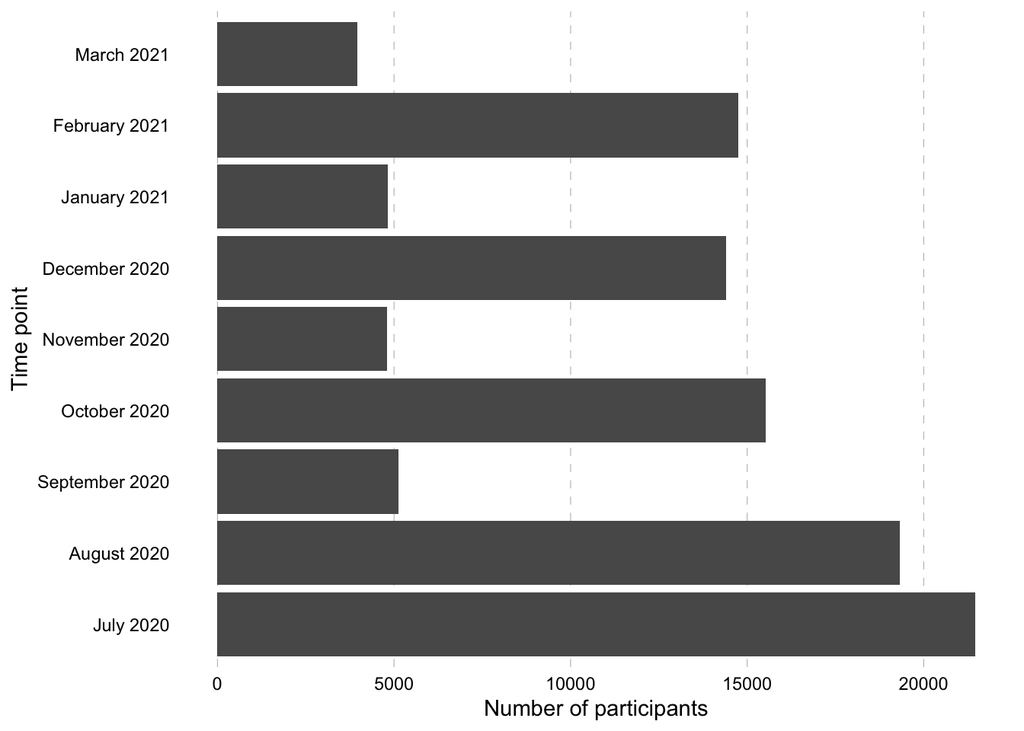

By sample

###*Plot sample size*

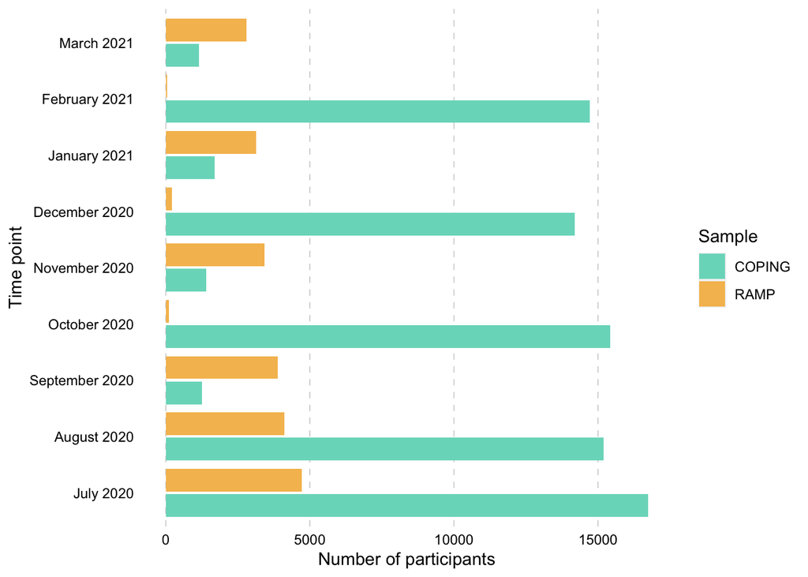

### Frequency of treatment seeking per wave

| wave | 0 | 1 | NA | total_responders | prop_responders |
| --- | --- | --- | --- | --- | --- |
| July 2020 | 3903 | 695 | 16854 | 4598 | 15.11527 |
| August 2020 | 15611 | 2430 | 1278 | 18041 | 13.46932 |
| September 2020 | 4001 | 771 | 359 | 4772 | 16.15675 |
| October 2020 | 12710 | 2008 | 813 | 14718 | 13.64316 |
| November 2020 | 3875 | 796 | 138 | 4671 | 17.04132 |
| December 2020 | 12129 | 1745 | 529 | 13874 | 12.57748 |
| January 2021 | 4013 | 712 | 94 | 4725 | 15.06878 |
| February 2021 | 12532 | 1841 | 379 | 14373 | 12.80874 |
| March 2021 | 3237 | 623 | 93 | 3860 | 16.13990 |

```
[1] 0.138954
```

```
[1] 14.66897
```

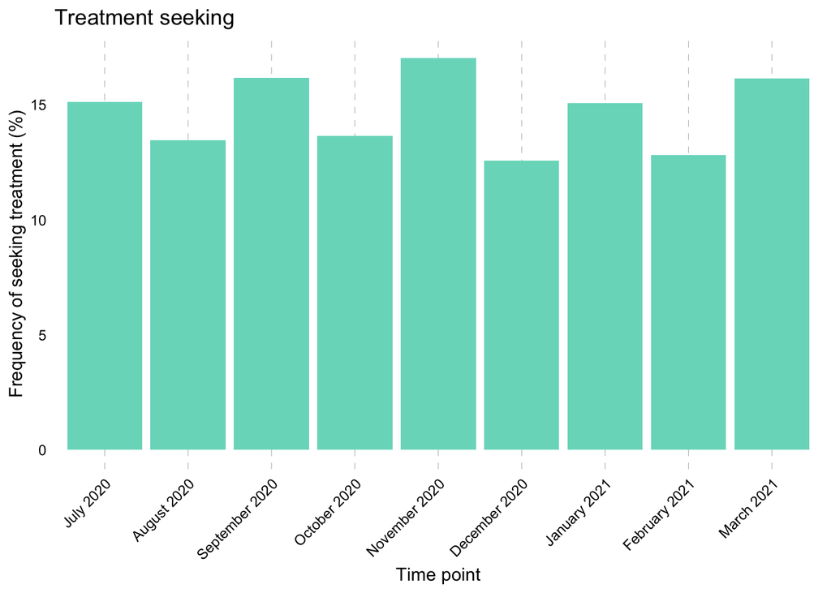

###*Plot treatment gap*

| wave | Received | Not received |
| --- | --- | --- |
| July 2020 | 87.76978 | 12.23022 |
| August 2020 | 83.20988 | 16.79012 |
| September 2020 | 82.36057 | 17.63943 |
| October 2020 | 82.17131 | 17.82869 |
| November 2020 | 81.15578 | 18.84422 |
| December 2020 | 84.52722 | 15.47278 |
| January 2021 | 81.46067 | 18.53933 |
| February 2021 | 85.33406 | 14.66594 |
| March 2021 | 81.05939 | 18.94061 |

```
[1] 16.77237
```

```
[1] 2.256685
```

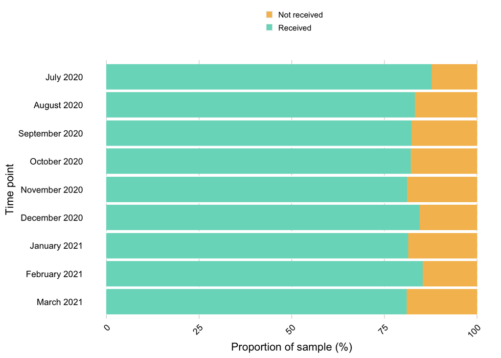

By sample

### Reason for seeking treatment by wave

| wave | Mental health crisis | Newly emerging symptoms | Seeking new treatment | Existing mental health concern |
| --- | --- | --- | --- | --- |
| July 2020 | 1.754386 | 25.81454 | 0.5012531 | 71.92982 |
| August 2020 | 1.154133 | 20.77439 | 0.7073716 | 77.36411 |
| September 2020 | 2.389486 | 22.70012 | 0.4778973 | 74.43250 |
| October 2020 | 1.808318 | 19.75588 | 0.6781193 | 77.75769 |
| November 2020 | 1.522248 | 22.71663 | 0.4683841 | 75.29274 |
| December 2020 | 1.519916 | 20.17820 | 0.6289308 | 77.67296 |
| January 2021 | 1.030928 | 21.52062 | 0.2577320 | 77.19072 |
| February 2021 | 1.051051 | 20.57057 | 0.3003003 | 78.07808 |
| March 2021 | 1.030928 | 23.26951 | 0.4418262 | 75.25773 |

###*Plot reason seek*

| wave | Mental health crisis | Newly emerging symptoms | Seeking new treatment | Existing mental health concern |
| --- | --- | --- | --- | --- |
| July 2020 | 1.754386 | 25.81454 | 0.5012531 | 71.92982 |
| August 2020 | 1.154133 | 20.77439 | 0.7073716 | 77.36411 |
| September 2020 | 2.389486 | 22.70012 | 0.4778973 | 74.43250 |
| October 2020 | 1.808318 | 19.75588 | 0.6781193 | 77.75769 |
| November 2020 | 1.522248 | 22.71663 | 0.4683841 | 75.29274 |
| December 2020 | 1.519916 | 20.17820 | 0.6289308 | 77.67296 |
| January 2021 | 1.030928 | 21.52062 | 0.2577320 | 77.19072 |
| February 2021 | 1.051051 | 20.57057 | 0.3003003 | 78.07808 |
| March 2021 | 1.030928 | 23.26951 | 0.4418262 | 75.25773 |

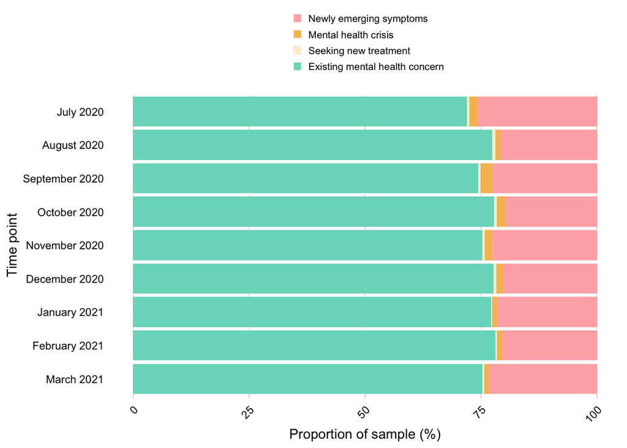

By sample

###*Plot reason not seek*

| reason | category | n | percent |
| --- | --- | --- | --- |
| Feel fine | Mild or no current symptoms | 40523 | 54.422509 |
| Feel better | Mild or no current symptoms | 2859 | 3.839645 |
| Not bad enough | Mild or no current symptoms | 18583 | 24.957024 |
| Don't think help available | Systemic | 3666 | 4.923449 |
| Bad past experience | Systemic | 3023 | 4.059898 |
| Didn't know where to find | Systemic | 1426 | 1.915122 |
| Too busy | Client | 2235 | 3.001612 |
| Want to but haven't | Client | 2145 | 2.880741 |
| Other | Other | 0 | 0.000000 |

| category | total | percent |
| --- | --- | --- |
| Client | 4380 | 5.882353 |
| Mild or no current symptoms | 61965 | 83.219178 |
| Other | 0 | 0.000000 |
| Systemic | 8115 | 10.898469 |

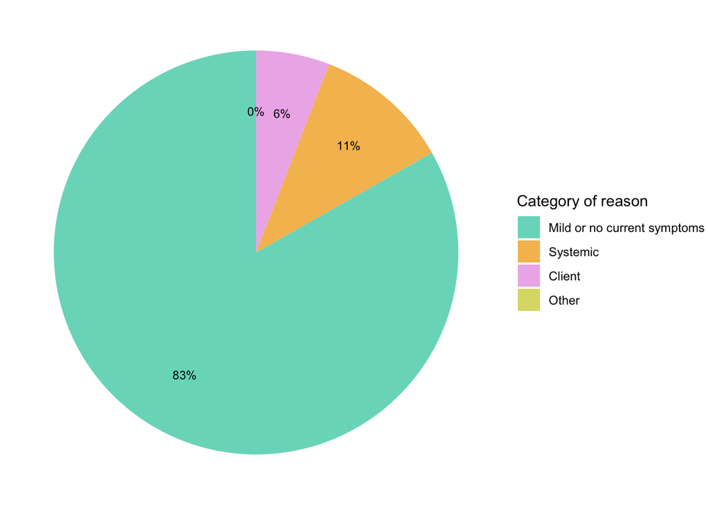

### Frequency of treatment receipt by type and wave (any instances of treatment, not total instances)

Seeking ANY instances of this type of treatment (i.e., if they sought supported help from 3 sources in a wave, it will just register once) BUT they might ALSO have sought help from both routes (i.e., if they sought help from a supported and self guided source, they will register in each of these categories. So we might expect to have more people in the supported + self guided categories per wave than we do who sought help for themselves above)

**Supported**

| wave | Did not seek supported treatment | Sought Supported |
| --- | --- | --- |
| July 2020 | 20871 | 581 |
| August 2020 | 17372 | 1947 |
| September 2020 | 4535 | 596 |
| October 2020 | 13945 | 1586 |
| November 2020 | 4197 | 612 |
| December 2020 | 13011 | 1392 |
| February 2021 | 13354 | 1398 |
| March 2021 | 3482 | 471 |

By sample

**Self guided**

| wave | Did not seek self-guided treatment | Sought Self-guided |
| --- | --- | --- |
| July 2020 | 21149 | 303 |
| August 2020 | 18320 | 999 |
| September 2020 | 4831 | 300 |
| October 2020 | 14794 | 737 |
| November 2020 | 4520 | 289 |
| December 2020 | 13724 | 679 |
| February 2021 | 14029 | 723 |
| March 2021 | 3731 | 222 |

**COMPARISON of FREQ of support type**

```
[1] 8583
```

```
[1] 66.87183
```

```
[1] 4252
```

```
[1] 33.12817
```

By sample

### Frequency of treatment seeking overall

Number of people who sought treatment at any point during the pandemic

```
Frequencies
treat_dat_byID$AnySeek
Type: Character

                                   Freq   % Valid   % Valid Cum.   % Total   % Total Cum.
------------------------------- ------- --------- -------------- --------- --------------
              Never sought help   21037     76.80          76.80     76.80          76.80
      Sought help at least once    6356     23.20         100.00     23.20         100.00
                           <NA>       0                               0.00         100.00
                          Total   27393    100.00         100.00    100.00         100.00
```

By sample

```
Frequencies
treat_dat_byIDSamp$AnySeek
Type: Character
Group: Sample = COPING

                                   Freq   % Valid   % Valid Cum.   % Total   % Total Cum.
------------------------------- ------- --------- -------------- --------- --------------
              Never sought help   16914     77.83          77.83     77.83          77.83
      Sought help at least once    4817     22.17         100.00     22.17         100.00
                           <NA>       0                               0.00         100.00
                          Total   21731    100.00         100.00    100.00         100.00

Group: Sample = RAMP

                                  Freq   % Valid   % Valid Cum.   % Total   % Total Cum.
------------------------------- ------ --------- -------------- --------- --------------
              Never sought help   4123     72.82          72.82     72.82          72.82
      Sought help at least once   1539     27.18         100.00     27.18         100.00
                           <NA>      0                               0.00         100.00
                          Total   5662    100.00         100.00    100.00         100.00
```

### Count table of treatment seeking across all waves

```
Frequencies
treat_dat_byID$n
Type: Numeric

               Freq   % Valid   % Valid Cum.   % Total   % Total Cum.
----------- ------- --------- -------------- --------- --------------
          0   21037     76.80          76.80     76.80          76.80
          1    3391     12.38          89.18     12.38          89.18
          2    1502      5.48          94.66      5.48          94.66
          3     825      3.01          97.67      3.01          97.67
          4     495      1.81          99.48      1.81          99.48
          5      87      0.32          99.80      0.32          99.80
          6      56      0.20         100.00      0.20         100.00
       <NA>       0                               0.00         100.00
      Total   27393    100.00         100.00    100.00         100.00
```

By sample

```
Frequencies
treat_dat_byIDSamp$n
Type: Numeric
Group: Sample = COPING

               Freq   % Valid   % Valid Cum.   % Total   % Total Cum.
----------- ------- --------- -------------- --------- --------------
          0   16914    77.834         77.834    77.834         77.834
          1    2655    12.218         90.051    12.218         90.051
          2    1151     5.297         95.348     5.297         95.348
          3     630     2.899         98.247     2.899         98.247
          4     376     1.730         99.977     1.730         99.977
          5       5     0.023        100.000     0.023        100.000
       <NA>       0                              0.000        100.000
      Total   21731   100.000        100.000   100.000        100.000

Group: Sample = RAMP

              Freq   % Valid   % Valid Cum.   % Total   % Total Cum.
----------- ------ --------- -------------- --------- --------------
          0   4123     72.82          72.82     72.82          72.82
          1    736     13.00          85.82     13.00          85.82
          2    351      6.20          92.02      6.20          92.02
          3    195      3.44          95.46      3.44          95.46
          4    119      2.10          97.56      2.10          97.56
          5     82      1.45          99.01      1.45          99.01
          6     56      0.99         100.00      0.99         100.00
       <NA>      0                               0.00         100.00
      Total   5662    100.00         100.00    100.00         100.00
```

### Count of the number of different sources from which treatment was sought, by treatment type, wave

Supported

By sample

Self guided

By sample

### Frequency of treatment receipt by wave (any instances of treatment, not total instances)

Receiving ANY instances of this type of treatment (i.e., if they sought and received supported help from 3 sources in a wave, it will just register once)

Supported

```
Frequencies
treat_dat$TypeReceived.Supported.Any
Type: Character
Group: wave = July 2020

                                             Freq   % Valid   % Valid Cum.   % Total   % Total Cum.
----------------------------------------- ------- --------- -------------- --------- --------------
      Did not receive supported treatment   20894     97.40          97.40     97.40          97.40
                       Received Supported     558      2.60         100.00      2.60         100.00
                                     <NA>       0                               0.00         100.00
                                    Total   21452    100.00         100.00    100.00         100.00

Group: wave = August 2020

                                             Freq   % Valid   % Valid Cum.   % Total   % Total Cum.
----------------------------------------- ------- --------- -------------- --------- --------------
      Did not receive supported treatment   17496     90.56          90.56     90.56          90.56
                       Received Supported    1823      9.44         100.00      9.44         100.00
                                     <NA>       0                               0.00         100.00
                                    Total   19319    100.00         100.00    100.00         100.00

Group: wave = September 2020

                                            Freq   % Valid   % Valid Cum.   % Total   % Total Cum.
----------------------------------------- ------ --------- -------------- --------- --------------
      Did not receive supported treatment   4562     88.91          88.91     88.91          88.91
                       Received Supported    569     11.09         100.00     11.09         100.00
                                     <NA>      0                               0.00         100.00
                                    Total   5131    100.00         100.00    100.00         100.00

Group: wave = October 2020

                                             Freq   % Valid   % Valid Cum.   % Total   % Total Cum.
----------------------------------------- ------- --------- -------------- --------- --------------
      Did not receive supported treatment   14052     90.48          90.48     90.48          90.48
                       Received Supported    1479      9.52         100.00      9.52         100.00
                                     <NA>       0                               0.00         100.00
                                    Total   15531    100.00         100.00    100.00         100.00

Group: wave = November 2020

                                            Freq   % Valid   % Valid Cum.   % Total   % Total Cum.
----------------------------------------- ------ --------- -------------- --------- --------------
      Did not receive supported treatment   4222     87.79          87.79     87.79          87.79
                       Received Supported    587     12.21         100.00     12.21         100.00
                                     <NA>      0                               0.00         100.00
                                    Total   4809    100.00         100.00    100.00         100.00

Group: wave = December 2020

                                             Freq   % Valid   % Valid Cum.   % Total   % Total Cum.
----------------------------------------- ------- --------- -------------- --------- --------------
      Did not receive supported treatment   13067     90.72          90.72     90.72          90.72
                       Received Supported    1336      9.28         100.00      9.28         100.00
                                     <NA>       0                               0.00         100.00
                                    Total   14403    100.00         100.00    100.00         100.00

Group: wave = January 2021

                                            Freq   % Valid   % Valid Cum.   % Total   % Total Cum.
----------------------------------------- ------ --------- -------------- --------- --------------
      Did not receive supported treatment   4290     89.02          89.02     89.02          89.02
                       Received Supported    529     10.98         100.00     10.98         100.00
                                     <NA>      0                               0.00         100.00
                                    Total   4819    100.00         100.00    100.00         100.00

Group: wave = February 2021

                                             Freq   % Valid   % Valid Cum.   % Total   % Total Cum.
----------------------------------------- ------- --------- -------------- --------- --------------
      Did not receive supported treatment   13333     90.38          90.38     90.38          90.38
                       Received Supported    1419      9.62         100.00      9.62         100.00
                                     <NA>       0                               0.00         100.00
                                    Total   14752    100.00         100.00    100.00         100.00

Group: wave = March 2021

                                            Freq   % Valid   % Valid Cum.   % Total   % Total Cum.
----------------------------------------- ------ --------- -------------- --------- --------------
      Did not receive supported treatment   3489     88.26          88.26     88.26          88.26
                       Received Supported    464     11.74         100.00     11.74         100.00
                                     <NA>      0                               0.00         100.00
                                    Total   3953    100.00         100.00    100.00         100.00
```

By sample

```
Frequencies
treat_dat$TypeReceived.SelfGuide.Any
Type: Character
Group: wave = July 2020

                                               Freq   % Valid   % Valid Cum.   % Total   % Total Cum.
------------------------------------------- ------- --------- -------------- --------- --------------
      Did not receive self-guided treatment   21207     98.86          98.86     98.86          98.86
                       Received Self-guided     245      1.14         100.00      1.14         100.00
                                       <NA>       0                               0.00         100.00
                                      Total   21452    100.00         100.00    100.00         100.00

Group: wave = August 2020

                                               Freq   % Valid   % Valid Cum.   % Total   % Total Cum.
------------------------------------------- ------- --------- -------------- --------- --------------
      Did not receive self-guided treatment   18503     95.78          95.78     95.78          95.78
                       Received Self-guided     816      4.22         100.00      4.22         100.00
                                       <NA>       0                               0.00         100.00
                                      Total   19319    100.00         100.00    100.00         100.00

Group: wave = September 2020

                                              Freq   % Valid   % Valid Cum.   % Total   % Total Cum.
------------------------------------------- ------ --------- -------------- --------- --------------
      Did not receive self-guided treatment   4876     95.03          95.03     95.03          95.03
                       Received Self-guided    255      4.97         100.00      4.97         100.00
                                       <NA>      0                               0.00         100.00
                                      Total   5131    100.00         100.00    100.00         100.00

Group: wave = October 2020

                                               Freq   % Valid   % Valid Cum.   % Total   % Total Cum.
------------------------------------------- ------- --------- -------------- --------- --------------
      Did not receive self-guided treatment   14891     95.88          95.88     95.88          95.88
                       Received Self-guided     640      4.12         100.00      4.12         100.00
                                       <NA>       0                               0.00         100.00
                                      Total   15531    100.00         100.00    100.00         100.00

Group: wave = November 2020

                                              Freq   % Valid   % Valid Cum.   % Total   % Total Cum.
------------------------------------------- ------ --------- -------------- --------- --------------
      Did not receive self-guided treatment   4576     95.15          95.15     95.15          95.15
                       Received Self-guided    233      4.85         100.00      4.85         100.00
                                       <NA>      0                               0.00         100.00
                                      Total   4809    100.00         100.00    100.00         100.00

Group: wave = December 2020

                                               Freq   % Valid   % Valid Cum.   % Total   % Total Cum.
------------------------------------------- ------- --------- -------------- --------- --------------
      Did not receive self-guided treatment   13826     95.99          95.99     95.99          95.99
                       Received Self-guided     577      4.01         100.00      4.01         100.00
                                       <NA>       0                               0.00         100.00
                                      Total   14403    100.00         100.00    100.00         100.00

Group: wave = January 2021

                                              Freq   % Valid   % Valid Cum.   % Total   % Total Cum.
------------------------------------------- ------ --------- -------------- --------- --------------
      Did not receive self-guided treatment   4587     95.19          95.19     95.19          95.19
                       Received Self-guided    232      4.81         100.00      4.81         100.00
                                       <NA>      0                               0.00         100.00
                                      Total   4819    100.00         100.00    100.00         100.00

Group: wave = February 2021

                                               Freq   % Valid   % Valid Cum.   % Total   % Total Cum.
------------------------------------------- ------- --------- -------------- --------- --------------
      Did not receive self-guided treatment   14074     95.40          95.40     95.40          95.40
                       Received Self-guided     678      4.60         100.00      4.60         100.00
                                       <NA>       0                               0.00         100.00
                                      Total   14752    100.00         100.00    100.00         100.00

Group: wave = March 2021

                                              Freq   % Valid   % Valid Cum.   % Total   % Total Cum.
------------------------------------------- ------ --------- -------------- --------- --------------
      Did not receive self-guided treatment   3757     95.04          95.04     95.04          95.04
                       Received Self-guided    196      4.96         100.00      4.96         100.00
                                       <NA>      0                               0.00         100.00
                                      Total   3953    100.00         100.00    100.00         100.00
```

By sample

### Frequency of treatment receipt by wave (total)

HOW MANY instances of treatment were received

Supported

```
Frequencies
treat_dat$TypeReceived.Supported.total
Type: Numeric
Group: wave = July 2020

               Freq   % Valid   % Valid Cum.   % Total   % Total Cum.
----------- ------- --------- -------------- --------- --------------
          0   20914    97.492         97.492    97.492         97.492
          1     350     1.632         99.124     1.632         99.124
          2     135     0.629         99.753     0.629         99.753
          3      40     0.186         99.939     0.186         99.939
          4       9     0.042         99.981     0.042         99.981
          5       4     0.019        100.000     0.019        100.000
       <NA>       0                              0.000        100.000
      Total   21452   100.000        100.000   100.000        100.000

Group: wave = August 2020

               Freq   % Valid   % Valid Cum.   % Total   % Total Cum.
----------- ------- --------- -------------- --------- --------------
          0   17558    90.885         90.885    90.885         90.885
          1    1177     6.092         96.977     6.092         96.977
          2     421     2.179         99.156     2.179         99.156
          3     118     0.611         99.767     0.611         99.767
          4      36     0.186         99.953     0.186         99.953
          5       9     0.047        100.000     0.047        100.000
       <NA>       0                              0.000        100.000
      Total   19319   100.000        100.000   100.000        100.000

Group: wave = September 2020

              Freq   % Valid   % Valid Cum.   % Total   % Total Cum.
----------- ------ --------- -------------- --------- --------------
          0   4576    89.183         89.183    89.183         89.183
          1    383     7.464         96.648     7.464         96.648
          2    134     2.612         99.259     2.612         99.259
          3     30     0.585         99.844     0.585         99.844
          4      7     0.136         99.981     0.136         99.981
          5      1     0.019        100.000     0.019        100.000
       <NA>      0                              0.000        100.000
      Total   5131   100.000        100.000   100.000        100.000

Group: wave = October 2020

               Freq   % Valid   % Valid Cum.   % Total   % Total Cum.
----------- ------- --------- -------------- --------- --------------
          0   14094    90.748         90.748    90.748         90.748
          1    1000     6.439         97.186     6.439         97.186
          2     315     2.028         99.214     2.028         99.214
          3      92     0.592         99.807     0.592         99.807
          4      26     0.167         99.974     0.167         99.974
          5       4     0.026        100.000     0.026        100.000
       <NA>       0                              0.000        100.000
      Total   15531   100.000        100.000   100.000        100.000

Group: wave = November 2020

              Freq   % Valid   % Valid Cum.   % Total   % Total Cum.
----------- ------ --------- -------------- --------- --------------
          0   4240    88.168         88.168    88.168         88.168
          1    388     8.068         96.236     8.068         96.236
          2    143     2.974         99.210     2.974         99.210
          3     30     0.624         99.834     0.624         99.834
          4      7     0.146         99.979     0.146         99.979
          5      1     0.021        100.000     0.021        100.000
       <NA>      0                              0.000        100.000
      Total   4809   100.000        100.000   100.000        100.000

Group: wave = December 2020

               Freq   % Valid   % Valid Cum.   % Total   % Total Cum.
----------- ------- --------- -------------- --------- --------------
          0   13113    91.044         91.044    91.044         91.044
          1     865     6.006         97.049     6.006         97.049
          2     311     2.159         99.208     2.159         99.208
          3      76     0.528         99.736     0.528         99.736
          4      29     0.201         99.938     0.201         99.938
          5       9     0.062        100.000     0.062        100.000
       <NA>       0                              0.000        100.000
      Total   14403   100.000        100.000   100.000        100.000

Group: wave = January 2021

              Freq   % Valid   % Valid Cum.   % Total   % Total Cum.
----------- ------ --------- -------------- --------- --------------
          0   4306    89.355         89.355    89.355         89.355
          1    340     7.055         96.410     7.055         96.410
          2    122     2.532         98.942     2.532         98.942
          3     36     0.747         99.689     0.747         99.689
          4     13     0.270         99.958     0.270         99.958
          5      2     0.042        100.000     0.042        100.000
       <NA>      0                              0.000        100.000
      Total   4819   100.000        100.000   100.000        100.000

Group: wave = February 2021

               Freq   % Valid   % Valid Cum.   % Total   % Total Cum.
----------- ------- --------- -------------- --------- --------------
          0   13379    90.693         90.693    90.693         90.693
          1     900     6.101         96.794     6.101         96.794
          2     349     2.366         99.159     2.366         99.159
          3      91     0.617         99.776     0.617         99.776
          4      28     0.190         99.966     0.190         99.966
          5       5     0.034        100.000     0.034        100.000
       <NA>       0                              0.000        100.000
      Total   14752   100.000        100.000   100.000        100.000

Group: wave = March 2021

              Freq   % Valid   % Valid Cum.   % Total   % Total Cum.
----------- ------ --------- -------------- --------- --------------
          0   3505    88.667         88.667    88.667         88.667
          1    284     7.184         95.851     7.184         95.851
          2    121     3.061         98.912     3.061         98.912
          3     34     0.860         99.772     0.860         99.772
          4      8     0.202         99.975     0.202         99.975
          5      1     0.025        100.000     0.025        100.000
       <NA>      0                              0.000        100.000
      Total   3953   100.000        100.000   100.000        100.000
```

By sample

**Self guided**

By sample

### Count of the number of different sources from which treatment was RECEIVED, by treatment type, wave

**Supported**

By sample

**Self guided**

By sample

### Frequency of systemic / client reasons for non-receipt by wave and treatment type

Barriers to receiving treatment by wave.

This section highlights the frequency of encountering AT LEAST ONE type of each barrier per person per barrier type per wave.

Does not capture anyone more than once per category. i.e. someone who encountered 3 barriers, 1 of which was sytemic, one was client level and one was other wit appear once for each category. A person who experienced 3 systemic barriers will only be counted once (under systemic)

#### For supported options**

**Systemic**

By sample

###*Plot overall reasons not received*

| reason | n | percent |
| --- | --- | --- |
| Systemic | 2738 | 38.67778 |
| Client | 2482 | 35.06145 |
| Other | 1859 | 26.26077 |

| reason | Self guided | Supported |
| --- | --- | --- |
| Systemic | 22.75804 | 46.65960 |
| Client | 50.76142 | 27.18982 |
| Other | 26.48054 | 26.15058 |

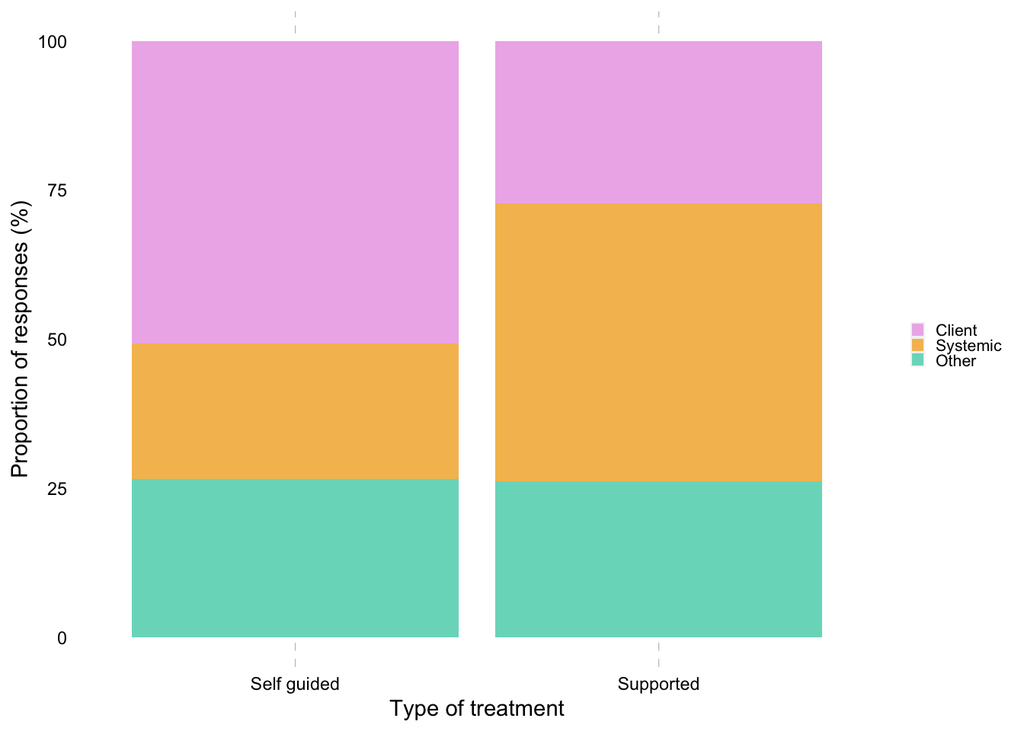

###*Plot reasons not received by source*

| source | Systemic | Client | Other | total |
| --- | --- | --- | --- | --- |
| Emergency mental health team | 392 | 207 | 150 | 749 |
| Existing mental health team | 760 | 277 | 307 | 1344 |
| GP | 952 | 393 | 477 | 1822 |
| Online talk therapy | 554 | 325 | 335 | 1214 |
| NHS 111 | 117 | 108 | 57 | 282 |
| Non NHS phone | 225 | 334 | 169 | 728 |
| Government website | 230 | 520 | 261 | 1011 |
| Non-government website | 176 | 469 | 237 | 882 |
| Online self-therapy | 129 | 268 | 140 | 537 |
| Structured therapeutic activity | 120 | 382 | 176 | 678 |

[output cut: 1 more lines]

| source | Systemic | Client | Other |
| --- | --- | --- | --- |
| Emergency mental health team | 52.33645 | 27.63685 | 20.02670 |
| Existing mental health team | 56.54762 | 20.61012 | 22.84226 |
| GP | 52.25027 | 21.56970 | 26.18002 |
| Online talk therapy | 45.63427 | 26.77100 | 27.59473 |
| NHS 111 | 41.48936 | 38.29787 | 20.21277 |
| Non NHS phone | 30.90659 | 45.87912 | 23.21429 |
| Government website | 22.74975 | 51.43422 | 25.81602 |
| Non-government website | 19.95465 | 53.17460 | 26.87075 |
| Online self-therapy | 24.02235 | 49.90689 | 26.07076 |
| Structured therapeutic activity | 17.69912 | 56.34218 | 25.95870 |

[output cut: 1 more lines]

[figure not shown]

**Client-level**

By sample

**Other**

By sample

#### For self guided options**

**Systemic**

By sample

**Client-level**

By sample

**Other**

By sample

### Barriers by agency by wave

#### Supported

*Emergency mental health team*

By sample

*Existing mental health team*

By sample

*Online talk therapy*

By sample

*GP*

By sample

*NHS 111*

By sample

*Non NHS phone*

By sample

#### Self guided

*Government website*

By sample

*Non-government website*

By sample

*Online self-therapy*

By sample

*Structured therapeutic activity*

By sample

### Frequency of different levels of helpfulness by treatment type (supported/client led) by wave

**For supported options**

By sample

**For client led options**

By sample

###*Plot helpfulness*

|  | Self guided | Supported | labels |
| --- | --- | --- | --- |
| Extremely unhelpful | 1.790355 | 2.800555 | Extremely unhelpful |
| Very unhelpful | 2.396766 | 3.393465 | Very unhelpful |
| Somewhat unhelpful | 5.342189 | 6.282326 | Somewhat unhelpful |
| Neither helpful nor unhelpful | 11.637309 | 7.518607 | Neither helpful nor unhelpful |
| Somewhat helpful | 45.134277 | 30.036584 | Somewhat helpful |
| Very helpful | 22.523823 | 27.866784 | Very helpful |
| Extremely helpful | 11.175282 | 22.101678 | Extremely helpful |

```
[1] 78.83338
```

```
[1] 80.00505
```

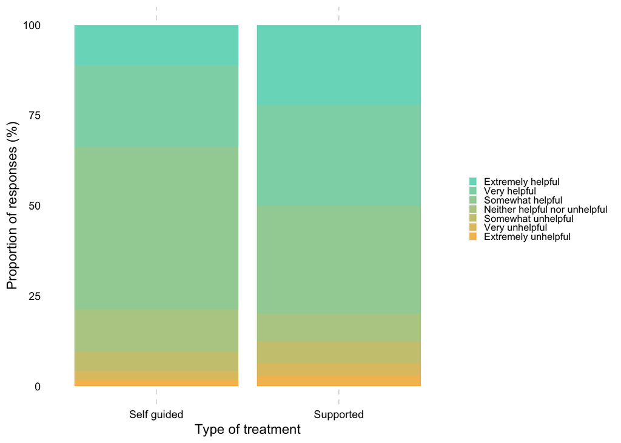

### Frequency of reasons for NOT seeking help

overall

## Gender and age stratification for barriers

Add gender and age to treatment data

```
Joining, by = c("ID", "Sample")
```

### Treatment seeking rates by Gender

```
[1] 5.216228e-251
```

```
    Pearson's Chi-squared test with Yates' continuity correction

data:  wide_tx_sought_mf[-1]
X-squared = 1145.1, df = 1, p-value < 2.2e-16
```

| Gender | 0 | 1 | prop_sought | prop_not_sought |
| --- | --- | --- | --- | --- |
| Male | 23292 | 1940 | 7.688649 | 92.31135 |
| Female | 49196 | 9711 | 16.485307 | 83.51469 |

```
[1] 84139
```

### Treatment seeking rates by Age

```
[1] 0
```

```
    Pearson's Chi-squared test

data:  wide_tx_sought_age[-1]
X-squared = 4974.4, df = 6, p-value < 2.2e-16
```

| AgeRecoded | 0 | 1 | prop_sought | prop_not_sought |
| --- | --- | --- | --- | --- |
| 16-25 | 2647 | 1396 | 34.528815 | 65.47118 |
| 26-35 | 6050 | 2115 | 25.903246 | 74.09675 |
| 36-45 | 7785 | 2160 | 21.719457 | 78.28054 |
| 46-55 | 14926 | 2649 | 15.072546 | 84.92745 |
| 56-65 | 22842 | 2082 | 8.353394 | 91.64661 |
| 66-75 | 16022 | 794 | 4.721694 | 95.27831 |
| 76+ | 1659 | 93 | 5.308219 | 94.69178 |

```
[1] 83220
```

###*Summary reasons not received - BY GENDER*

| reason | Self guided | Supported |
| --- | --- | --- |
| Systemic | 21.87182 | 46.56647 |
| Client | 52.44151 | 26.58720 |
| Other | 25.68667 | 26.84633 |

| reason | Self guided | Supported |
| --- | --- | --- |
| Systemic | 26.51515 | 47.45562 |
| Client | 46.21212 | 30.53254 |
| Other | 27.27273 | 22.01183 |

| reason | Self guided | Supported |
| --- | --- | --- |
| Systemic | 25.80645 | 50.00000 |
| Client | 38.70968 | 20.37037 |
| Other | 35.48387 | 29.62963 |

###*Summary reasons not received - BY AGE*

| reason | Self guided | Supported |
| --- | --- | --- |
| Systemic | 18.00643 | 47.92793 |
| Client | 58.19936 | 30.99099 |
| Other | 23.79421 | 21.08108 |

| reason | Self guided | Supported |
| --- | --- | --- |
| Systemic | 22.46377 | 46.43338 |
| Client | 51.69082 | 24.89906 |
| Other | 25.84541 | 28.66756 |

| reason | Self guided | Supported |
| --- | --- | --- |
| Systemic | 20.62084 | 46.30262 |
| Client | 55.87583 | 26.16610 |
| Other | 23.50333 | 27.53129 |

| reason | Self guided | Supported |
| --- | --- | --- |
| Systemic | 23.67491 | 46.92641 |
| Client | 50.17668 | 28.22511 |
| Other | 26.14841 | 24.84848 |

| reason | Self guided | Supported |
| --- | --- | --- |
| Systemic | 27.85388 | 45.31422 |
| Client | 41.78082 | 27.12238 |
| Other | 30.36530 | 27.56340 |

| reason | Self guided | Supported |
| --- | --- | --- |
| Systemic | 22.22222 | 46.61922 |
| Client | 43.51852 | 27.75801 |
| Other | 34.25926 | 25.62278 |

| reason | Self guided | Supported |
| --- | --- | --- |
| Systemic | 22.22222 | 42.85714 |
| Client | 44.44444 | 28.57143 |
| Other | 33.33333 | 28.57143 |

###**Chi square test Gender by reasons for not receiving treatment**

```
[1] 0.005778571
```

```
    Pearson's Chi-squared test

data:  reasons_gender_supported[-1]
X-squared = 10.307, df = 2, p-value = 0.005779
```

```
[1] 4704
```

```
[1] 0.05116081
```

```
    Pearson's Chi-squared test

data:  reasons_gender_sg[-1]
X-squared = 5.9456, df = 2, p-value = 0.05116
```

```
[1] 2362
```

###**Chi square test AGE by reasons for not receiving treatment**

```
[1] 0.229476
```

```
    Pearson's Chi-squared test

data:  reasons_age_supported[, c(-1)]
X-squared = 15.223, df = 12, p-value = 0.2295
```

```
[1] 4548
```

```
[1] 0.002148649
```

```
    Pearson's Chi-squared test

data:  reasons_age_selfguided[, c(-1)]
X-squared = 30.752, df = 12, p-value = 0.002149
```

```
[1] 2297
```

###**Plot Gender by reasons for not receiving treatment**

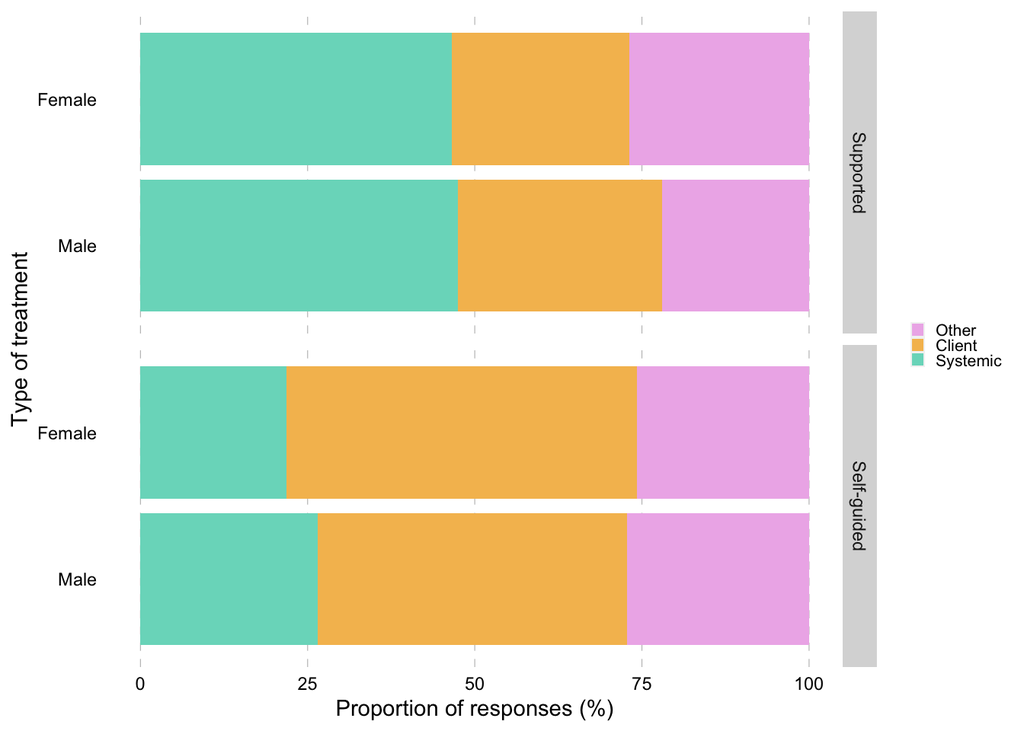

###**Plot Age by reasons for not receiving treatment**

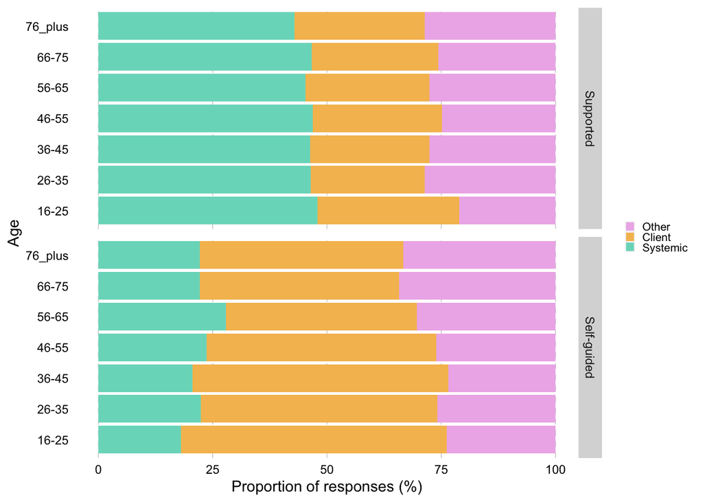

###**Chi square test Gender by Type of treatment sought**

```
[1] "prop_sought_supported_nbsd: "
```

```
[1] 69.42675
```

```
[1] "prop_sought_selfguided_nbsd: "
```

```
[1] 30.57325
```

```
    Pearson's Chi-squared test with Yates' continuity correction

data:  wide_tx_prop_mf[-1]
X-squared = 1.8916, df = 1, p-value = 0.169
```

| Gender | Supported | Self guided | prop_supported | prop_selfguided |
| --- | --- | --- | --- | --- |
| Male | 1536 | 725 | 0.6793454 | 0.3206546 |
| Female | 7586 | 3836 | 0.6641569 | 0.3358431 |

```
[1] 13683
```

###**Chi square test Age by Type of treatment sought**

```
    Pearson's Chi-squared test

data:  wide_tx_prop_age[1:7, 2:3]
X-squared = 17.029, df = 6, p-value = 0.009176
```

| AgeRecoded | Supported | Self guided | prop_supported | prop_selfguided |
| --- | --- | --- | --- | --- |
| 16-25 | 1117 | 608 | 64.75362 | 35.24638 |
| 26-35 | 1586 | 809 | 66.22129 | 33.77871 |
| 36-45 | 1665 | 838 | 66.52018 | 33.47982 |
| 46-55 | 2181 | 1107 | 66.33212 | 33.66788 |
| 56-65 | 1661 | 798 | 67.54778 | 32.45222 |
| 66-75 | 597 | 230 | 72.18863 | 27.81137 |
| 76+ | 58 | 21 | 73.41772 | 26.58228 |

```
[1] 13276
```

###**Plot Gender by Type of treatment sought**

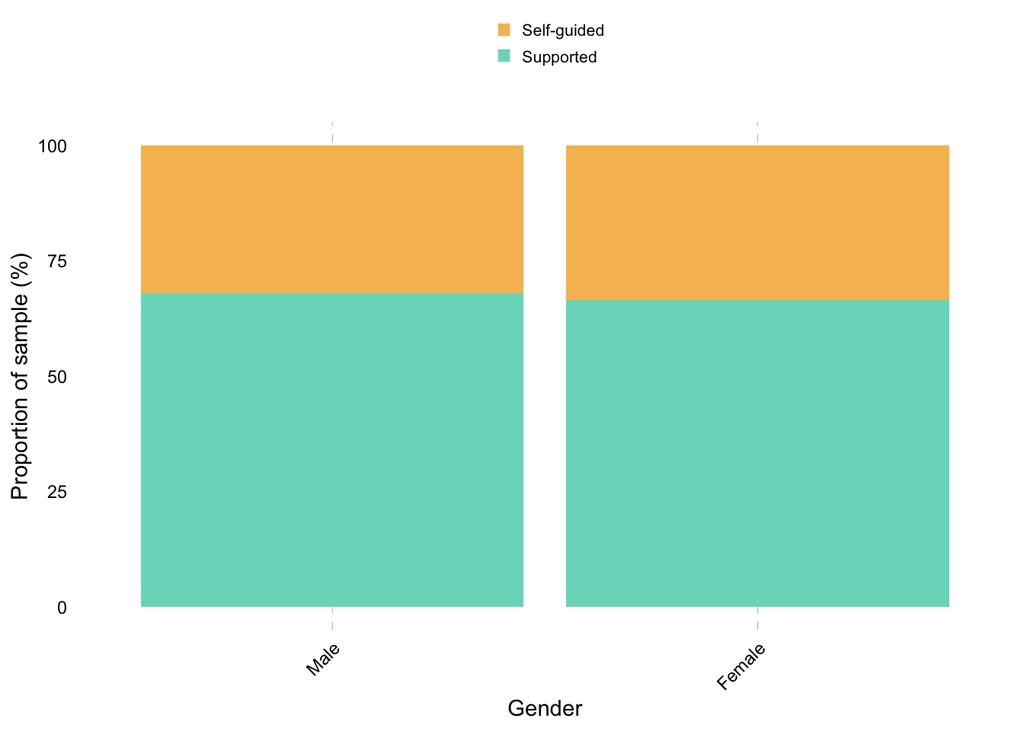

###**Plot Age by Type of treatment sought**

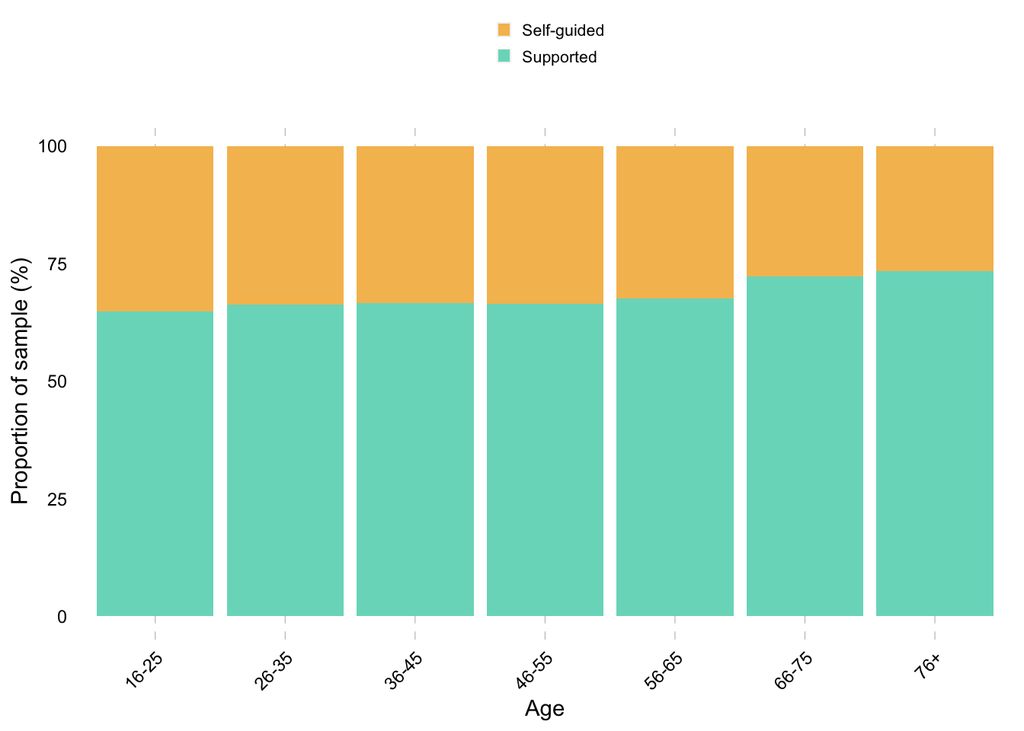

###**Chi square test Gender by Treatment seeking and gap**

```
[1] "Proportion of NB-SD gender seeking treatment: "
```

| sought | not_sought | prop_sought | prop_not_sought |
| --- | --- | --- | --- |
| 255 | 431 | 37.17201 | 62.82799 |

```
[1] "Proportion of NB-SD gender receiving treatment: "
```

| received | not_received | prop_received | prop_not_received |
| --- | --- | --- | --- |
| 217 | 38 | 85.09804 | 14.90196 |

```
[1] "Gender treatment seeking chisq: "
```

```
    Pearson's Chi-squared test with Yates' continuity correction

data:  treat_dat_seek_gender[-1]
X-squared = 1145.1, df = 1, p-value < 2.2e-16
```

| Gender | n not sought | n sought | prop_sought | prop_not_sought |
| --- | --- | --- | --- | --- |
| Male | 23292 | 1940 | 0.07688649 | 0.9231135 |
| Female | 49196 | 9711 | 0.16485307 | 0.8351469 |

```
[1] "Gender treatment receipt chisq: "
```

```
    Pearson's Chi-squared test with Yates' continuity correction

data:  treat_dat_gap_gender[-1]
X-squared = 12.074, df = 1, p-value = 0.0005112
```

| Gender | n received | n not received | prop_received | prop_not_received |
| --- | --- | --- | --- | --- |
| Male | 1563 | 377 | 0.8056701 | 0.1943299 |
| Female | 8140 | 1571 | 0.8382247 | 0.1617753 |

```
[1] 11651
```

###**Chi square test AGE by Treatment seeking and gap**

```
[1] "Age treatment seeking chisq: "
```

```
    Pearson's Chi-squared test

data:  treat_dat_seek_age[-1]
X-squared = 4974.4, df = 6, p-value < 2.2e-16
```

| AgeRecoded | n not sought | n sought | prop_sought | prop_not_sought |
| --- | --- | --- | --- | --- |
| 16-25 | 2647 | 1396 | 34.528815 | 65.47118 |
| 26-35 | 6050 | 2115 | 25.903246 | 74.09675 |
| 36-45 | 7785 | 2160 | 21.719457 | 78.28054 |
| 46-55 | 14926 | 2649 | 15.072546 | 84.92745 |
| 56-65 | 22842 | 2082 | 8.353394 | 91.64661 |
| 66-75 | 16022 | 794 | 4.721694 | 95.27831 |
| 76+ | 1659 | 93 | 5.308219 | 94.69178 |

```
[1] 83220
```

```
[1] "Age treatment receipt chisq: "
```

```
    Pearson's Chi-squared test

data:  treat_dat_gap_age[-1]
X-squared = 101.67, df = 6, p-value < 2.2e-16
```

| AgeRecoded | n received | n not received | prop_received | prop_not_received |
| --- | --- | --- | --- | --- |
| 16-25 | 1203 | 193 | 86.17479 | 13.82521 |
| 26-35 | 1794 | 321 | 84.82270 | 15.17730 |
| 36-45 | 1772 | 388 | 82.03704 | 17.96296 |
| 46-55 | 2258 | 391 | 85.23971 | 14.76029 |
| 56-65 | 1676 | 406 | 80.49952 | 19.50048 |
| 66-75 | 605 | 189 | 76.19647 | 23.80353 |
| 76+ | 54 | 39 | 58.06452 | 41.93548 |

```
[1] 11289
```

###*Plot treatment seeking by gender*

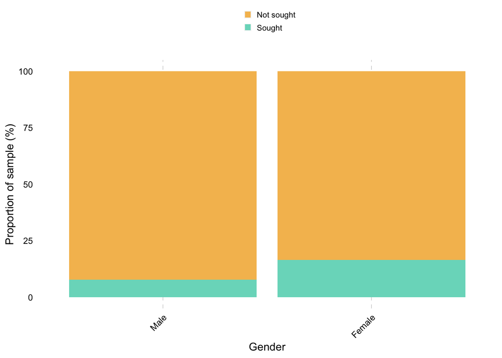

###*Plot treatment seeking by age*

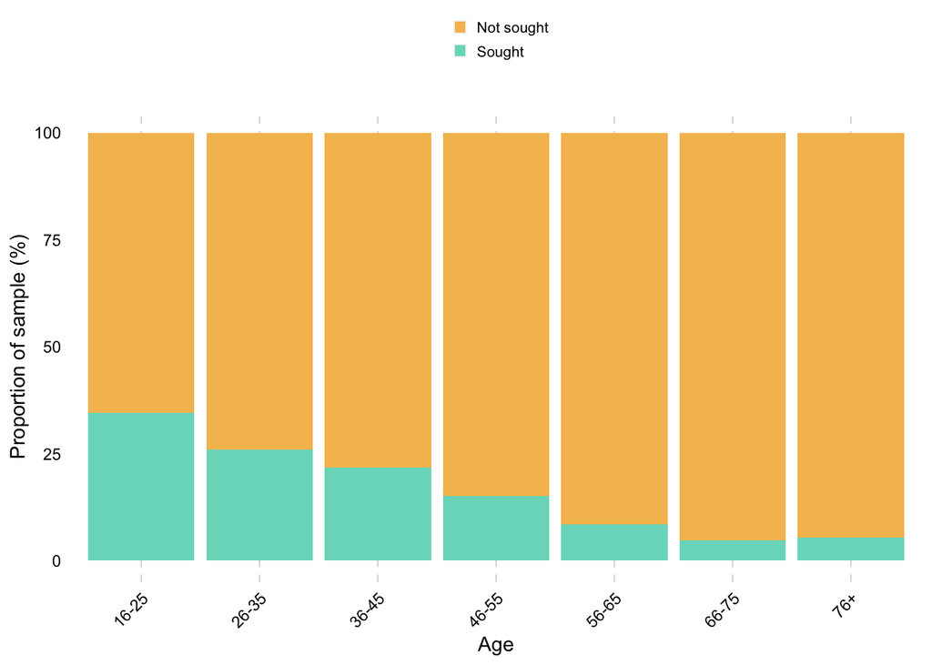

###*Plot treatment gap by gender*

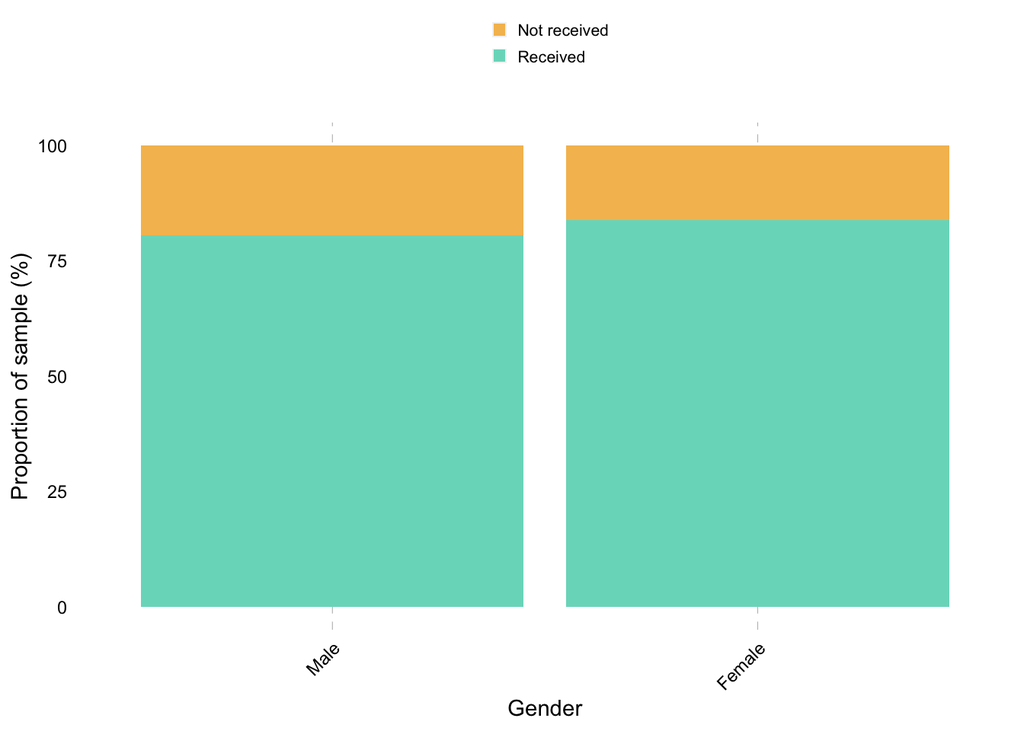

###*Plot treatment gap by age*

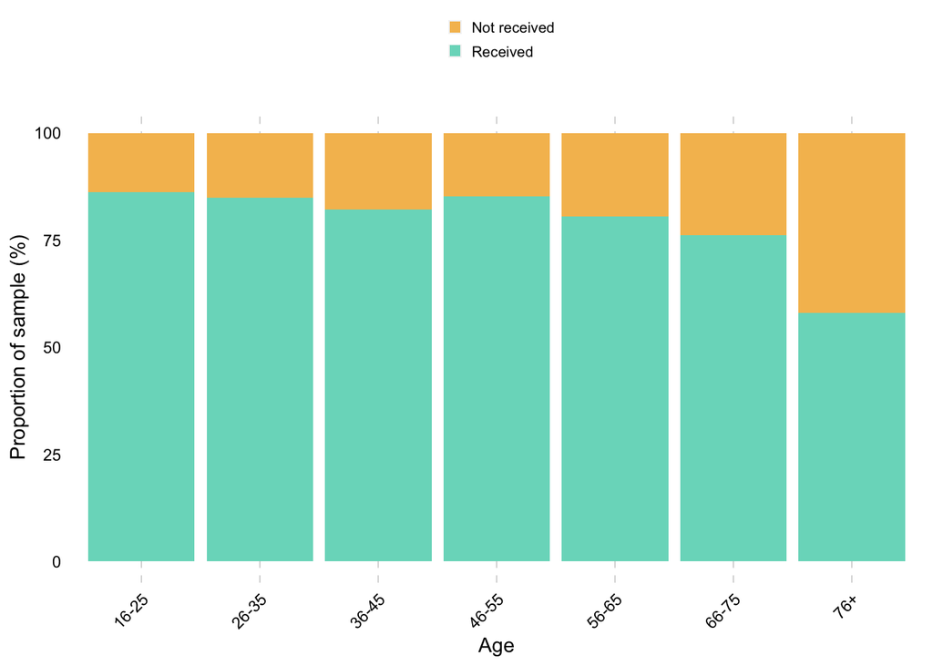

By sample

###**Ordinal logistic regression: tx_type*helpfulness**

```
Loading required package: MASS
```

```
Call:
polr(formula = labels ~ Type + n, data = long_helpfulness_freq,
    Hess = TRUE)

Coefficients:
                   Value Std. Error  t value
TypeSupported  2.004e-02   1.010605  0.01983
n             -3.293e-05   0.000701 -0.04698

Intercepts:
                                                  Value   Std. Error t value
Extremely helpful|Extremely unhelpful             -1.8084  0.9612    -1.8814
Extremely unhelpful|Neither helpful nor unhelpful -0.9341  0.8374    -1.1155
Neither helpful nor unhelpful|Somewhat helpful    -0.3088  0.8308    -0.3716
Somewhat helpful|Somewhat unhelpful                0.2655  0.8403     0.3160
Somewhat unhelpful|Very helpful                    0.8945  0.8735     1.0240
Very helpful|Very unhelpful                        1.7707  0.9974     1.7752

Residual Deviance: 54.48258
AIC: 70.48258
```

```
                                                          Value   Std. Error
TypeSupported                                      2.004328e-02 1.0106050058
n                                                 -3.292899e-05 0.0007009862
Extremely helpful|Extremely unhelpful             -1.808445e+00 0.9612457753
Extremely unhelpful|Neither helpful nor unhelpful -9.341211e-01 0.8373890316
Neither helpful nor unhelpful|Somewhat helpful    -3.087573e-01 0.8308294383
Somewhat helpful|Somewhat unhelpful                2.655378e-01 0.8402630639
Somewhat unhelpful|Very helpful                    8.945000e-01 0.8735061874
Very helpful|Very unhelpful                        1.770669e+00 0.9974365558
                                                      t value    p value
TypeSupported                                      0.01983295 0.98417663
n                                                 -0.04697523 0.96253297
Extremely helpful|Extremely unhelpful             -1.88135558 0.05992356
Extremely unhelpful|Neither helpful nor unhelpful -1.11551626 0.26462925
Neither helpful nor unhelpful|Somewhat helpful    -0.37162541 0.71017176
Somewhat helpful|Somewhat unhelpful                0.31601746 0.75198925
Somewhat unhelpful|Very helpful                    1.02403393 0.30581925
Very helpful|Very unhelpful                        1.77521956 0.07586164
```

```
                     2.5 %      97.5 %
TypeSupported -1.975134027 2.046786511
n             -0.001276733 0.001175151
```

###**Ordinal logistic regression: gender*helpfulness**

####Effect of gender on helpfulness: self-guided interventions

```
Call:
polr(formula = labels ~ Gender + n, data = long_MF_helpful_self_guide,
    Hess = TRUE)

Coefficients:
               Value Std. Error t value
GenderMale 0.0681066   1.101311 0.06184
n          0.0001689   0.001507 0.11206

Intercepts:
                                                  Value   Std. Error t value
Extremely helpful|Extremely unhelpful             -1.7158  1.1073    -1.5495
Extremely unhelpful|Neither helpful nor unhelpful -0.8357  1.0234    -0.8166
Neither helpful nor unhelpful|Somewhat helpful    -0.2001  1.0376    -0.1929
Somewhat helpful|Somewhat unhelpful                0.3761  1.0439     0.3603
Somewhat unhelpful|Very helpful                    1.0018  1.0560     0.9486
Very helpful|Very unhelpful                        1.8750  1.1501     1.6303

Residual Deviance: 54.47117
AIC: 70.47117
```

```
                                                          Value  Std. Error
GenderMale                                         0.0681065870 1.101310790
n                                                  0.0001688585 0.001506855
Extremely helpful|Extremely unhelpful             -1.7157733543 1.107293696
Extremely unhelpful|Neither helpful nor unhelpful -0.8357208479 1.023394177
Neither helpful nor unhelpful|Somewhat helpful    -0.2001008456 1.037582407
Somewhat helpful|Somewhat unhelpful                0.3760895613 1.043913072
Somewhat unhelpful|Very helpful                    1.0017763275 1.056037952
Very helpful|Very unhelpful                        1.8750306985 1.150099584
                                                      t value    p value
GenderMale                                         0.06184139 0.98417663
n                                                  0.11206021 0.96253297
Extremely helpful|Extremely unhelpful             -1.54951966 0.05992356
Extremely unhelpful|Neither helpful nor unhelpful -0.81661677 0.26462925
Neither helpful nor unhelpful|Somewhat helpful    -0.19285297 0.71017176
Somewhat helpful|Somewhat unhelpful                0.36026904 0.75198925
Somewhat unhelpful|Very helpful                    0.94861773 0.30581925
Very helpful|Very unhelpful                        1.63032030 0.07586164
```

```
                 2.5 %      97.5 %
GenderMale -2.12202161 2.242162163
n          -0.00274299 0.003165865
```

####Effect of gender on helpfulness: supported interventions

```
Call:
polr(formula = labels ~ Gender + n, data = long_MF_helpful_supported,
    Hess = TRUE)

Coefficients:
                Value Std. Error  t value
GenderMale -0.1038141  1.1795710 -0.08801
n          -0.0001293  0.0009543 -0.13549

Intercepts:
                                                  Value   Std. Error t value
Extremely helpful|Extremely unhelpful             -1.9122  1.2364    -1.5466
Extremely unhelpful|Neither helpful nor unhelpful -1.0373  1.1360    -0.9132
Neither helpful nor unhelpful|Somewhat helpful    -0.4159  1.1446    -0.3634
Somewhat helpful|Somewhat unhelpful                0.1565  1.1597     0.1350
Somewhat unhelpful|Very helpful                    0.7841  1.1921     0.6578
Very helpful|Very unhelpful                        1.6599  1.2889     1.2878

Residual Deviance: 54.46325
AIC: 70.46325
```

```
                                                          Value   Std. Error
GenderMale                                        -0.1038140720 1.1795710185
n                                                 -0.0001293004 0.0009543243
Extremely helpful|Extremely unhelpful             -1.9122159865 1.2363762254
Extremely unhelpful|Neither helpful nor unhelpful -1.0373221062 1.1359687636
Neither helpful nor unhelpful|Somewhat helpful    -0.4159217035 1.1446376917
Somewhat helpful|Somewhat unhelpful                0.1565226632 1.1597134495
Somewhat unhelpful|Very helpful                    0.7841363699 1.1920789398
Very helpful|Very unhelpful                        1.6599194271 1.2889284386
                                                      t value    p value
GenderMale                                        -0.08801002 0.98417663
n                                                 -0.13548900 0.96253297
Extremely helpful|Extremely unhelpful             -1.54662953 0.05992356
Extremely unhelpful|Neither helpful nor unhelpful -0.91316077 0.26462925
Neither helpful nor unhelpful|Somewhat helpful    -0.36336537 0.71017176
Somewhat helpful|Somewhat unhelpful                0.13496667 0.75198925
Somewhat unhelpful|Very helpful                    0.65778896 0.30581925
Very helpful|Very unhelpful                        1.28782900 0.07586164
```

```
                  2.5 %      97.5 %
GenderMale -2.459537348 2.200890224
n          -0.001938625 0.001572194
```

####**Effect of gender on helpfulness: plots**

### Reasons by gender

*Emergency mental health team*

By sample

*Existing mental health team*

By sample

*Online talk therapy*

By sample

*GP*

By sample

*NHS 111*

By sample

*Non NHS phone*

By sample

#### Self guided

*Government website*

By sample

*Non-government website*

By sample

*Online self-therapy*

By sample

*Structured therapeutic activity*

By sample

### Why not seek treatment by gender

### Frequency of different levels of helpfulness by treatment type (supported/client led) by wave by gender

**For supported options**

By sample

**For client led options**

By sample

## *Multi-panel plot*

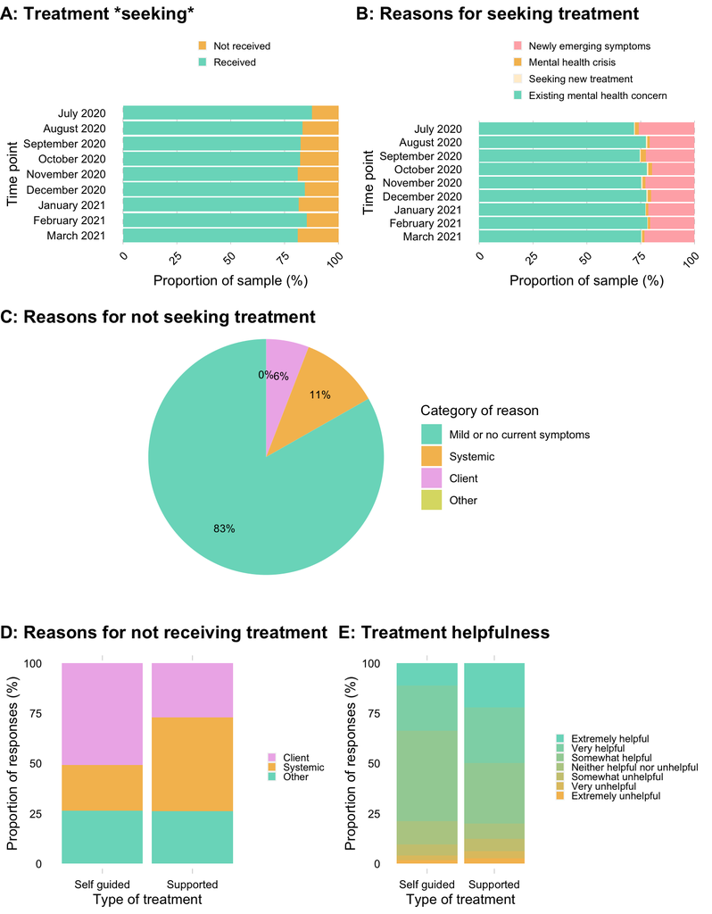

## *Gender multi-panel plot*

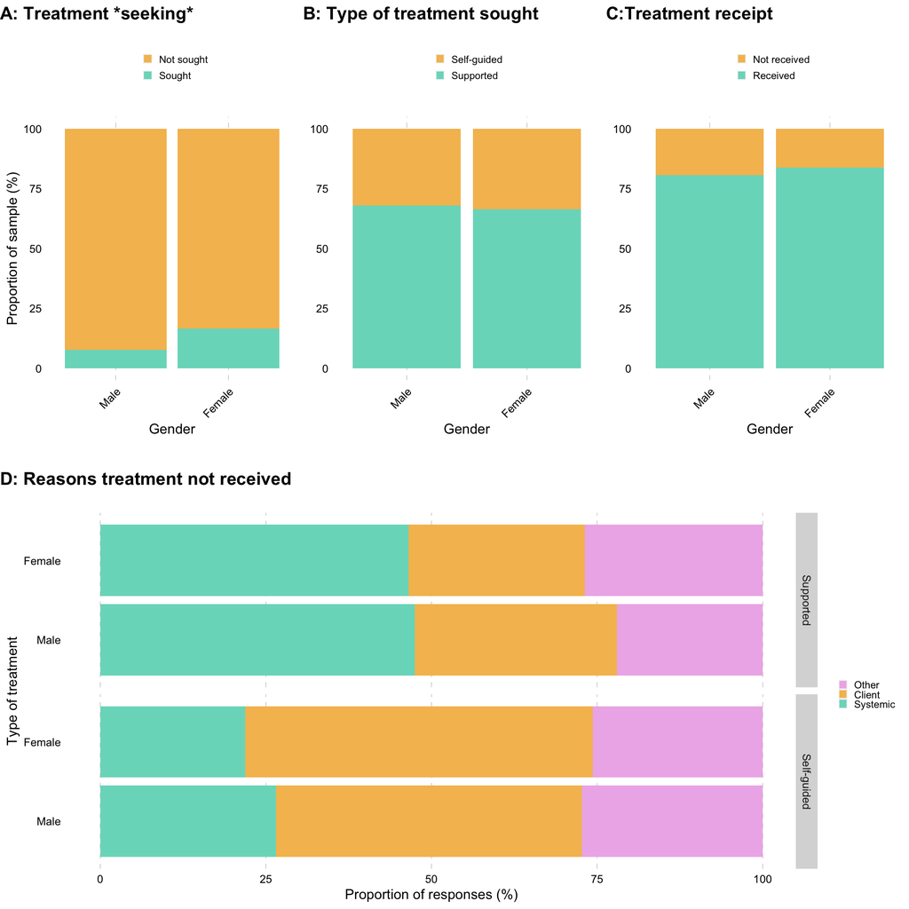

## *Age multi-panel plot*

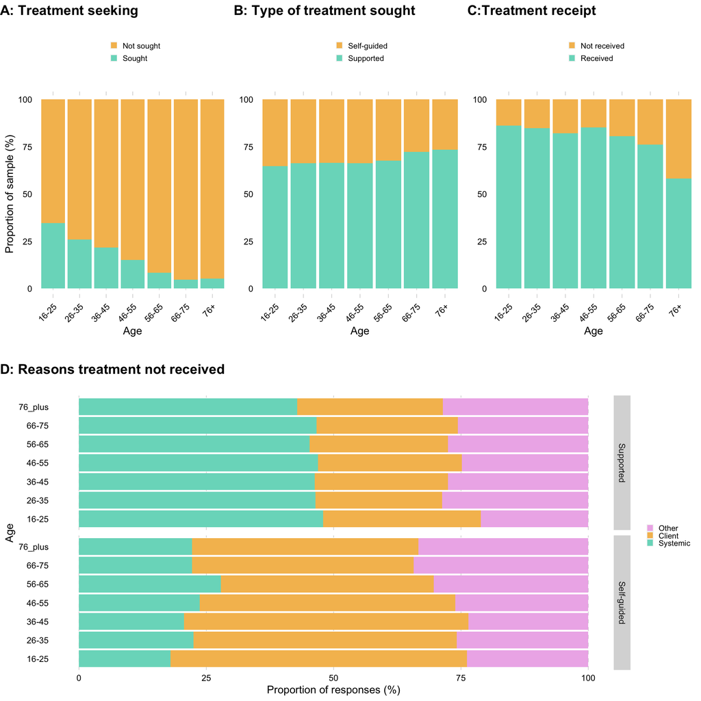

## Geographic

Project postcode data onto map of the UK. Use downloaded long/lat data mapped to postcodes from [this site](https://www.freemaptools.com/download-uk-postcode-lat-lng.htm) and city names from [here](https://www.doogal.co.uk/UKPostcodes.php).

### Create clean, labelled and flat outcode dataset

### Create counts of treatment seeking and barriers by region

#### read in map libraries

### Merge sample data to downloaded UK data

### create counts by county and district

check county data

check district data

## test building a UK map with districts plotted

## Seeking attempts by total responses maps

### Treatment seeking by county (no labels)

Size of the circles = total number of responses Colour of circles = percent of responses that indicated treatment seeking

### Treatment seeking by district (no labels)

Size of the circles = total number of responses Colour of circles = percent of responses that indicated treatment seeking

### Labelled the 5 counties ith greatest proporton seeking by total responses

#### county

#### district labelled with marker points for most percentage seek attempts by responses

orange markers for top 5 biggest gap, with labels

#### district labelled with marker points (no labels)

orange markers for top 5 biggest gap, WITHOUT labels

#### district - only top ten gap treatment seeking attemps

## Treatment gaps by total treatment seeking

### Treatment gap by county (no labels)

Size of the circles = total number of seeking attempts Colour of circles = percent of times treatment was not received when it was sought

### Treatment gap by district (no labels)

Size of the circles = total number of responses Colour of circles = percent of responses that indicated treatment gap

### Labelled the 5 counties ith greatest proporton gap by total responses

#### county

#### district labelled with marker points for most percentage seek attempts by responses

orange markers for top 5 biggest gap, with labels

#### district labelled with marker points (no labels)

orange markers for top 5 biggest gap, WITHOUT labels

#### district - only top ten gap treatment gap attemps

Filtered to districts where fewer than 5 seek attempts in the district

## Mapping alongside indices of multiple deprivation

used most recent in all cases (2019 for England and Wales, 2020 for Scotland, 2017 for Northern Ireland)

### Indices of multiple deprivation were downloaded from:

[England](https://opendatacommunities.org/resource?uri=http%3A%2F%2Fopendatacommunities.org%2Fdata%2Fsocietal-wellbeing%2Fimd2019%2Findices) [Ireland](https://www.nisra.gov.uk/publications/nimdm17-soa-level-results) [Scotland](https://www.gov.scot/publications/scottish-index-of-multiple-deprivation-2020v2-ranks/) *note: using the revised 2020 version for Scotland. See note on Website. Description of indicators is available on sheet 2 of excel downloaded from this link* [Wales](https://statswales.gov.wales/Catalogue/Community-Safety-and-Social-Inclusion/Welsh-Index-of-Multiple-Deprivation/WIMD-2019/localauthorityanalysis)

### Shapefiles for mapping districts were downloaded from:

[GB (excluding Ireland)](https://www.ordnancesurvey.co.uk/business-government/products/boundaryline) [IRE](https://www.opendatani.gov.uk/dataset/osni-open-data-largescale-boundaries-ni-outline1)

Projection of shapefiles converted to the Ordnance Survey Great Britain 1936 system (OSGB36 - EPSG code: 27700) to project into common space

### Notes

Using MDI rank for the time being - so ranks within each boundary will be comparable

## clean IMD data

## create shapefiles for maps with polygons for plotting district boundaries

## combine the IMD and shapefiles

## Plot IMD on map

### only IMD

### with treatmetn seeking

### with treatment gap

## Analytic decision notes

### Including cohort as a covariate

This would likely be a collider (sx severity is going to be associated with both cohort and treatment seeking)

#### NOTE TO SELF:: fix any treatment barrier stuff

#### make sure the counts are referring to the right thing!